# Trabajo Final

Reinier Mujica

13 de enero de 2019

### Inicialización

Limpiamos todas las variables del espacio de trabajo y el terminal de R.

```r
rm(list=ls())
cat("\014")
```

```r
library(knitr)
```

Cargamos el paquete de wooldridge y los datos

```r
library(wooldridge)
attach(bwght2)
```

Fijamos la semilla

```r
set.seed(100)
```

### Limpiar los datos

Vamos a remover los valores NA de los datos

```r
datos = na.omit(bwght2)
```

### División del conjunto de datos

```r
train.size = round(dim(datos)[1] * 0.7)
train = sample(1:dim(datos)[1], train.size)
test = -train
datos.train = datos[train, ]
datos.test = datos[test, ]
test.size = dim(datos.test)[1]
```

### Preguntas:

#### a)

El conjunto de datos es bwght2 y contiene información sobre nacimientos. Estos datos han sido obtenidos de certificados de nacimiento y desfunción y también de información de natalidad y mortalidad del Centro Nacional de Estadística para la Salud. El dataset contiene varias variables con diversa información como: edad de los padres, educación de los padres, número de visitas prenatales, peso al nacer, e información acerca de la cantidad de cigarillos y bebida que consumia la madre durante el embarazo. También se incluye información del feto.

Los nombres de las variables que contiene el dataset son:

```
 [1] "mage"    "meduc"   "monpre"  "npvis"   "fage"    "feduc"   "bwght"
 [8] "omaps"   "fmaps"   "cigs"    "drink"   "lbw"     "vlbw"    "male"
[15] "mwhte"   "mblck"   "moth"    "fwhte"   "fblck"   "foth"    "lbwght"
[22] "magesq"  "npvissq"
```

La variable dependiente que va ha ser explicada es **lbwght**, que es el logaritmo de la variable **bwght** que es el peso al nacer.

Vamos a ajustar un modelo de mínimos cuadrados ordinarios (con todas las variables explicativas) en el conjunto de entrenamiento e imprimir el error de prueba obtenido.

```
[1] 0.000518739
```

Creamos una tabla para guardar los resultados de todos los modelos

```r
results <- matrix(NA, nrow = 3, ncol = 3)
colnames(results) <- c("None","5 Cross Validation","10 Cross Validation")
rownames(results) <- c("MCO","MCO with Subset Selection","MCO with Forward step wise")
results <- as.table(results)

results["MCO", "None"] = error.mco
```

Los datos del modelo y los coeficientes B los podemos ver a continuación.

```r
summary(lm.fit)
```

```
Call:
lm(formula = lbwght ~ ., data = datos.train)

Residuals:
     Min       1Q   Median       3Q      Max
-0.51085 -0.00469  0.00483  0.01096  0.25896

Coefficients: (2 not defined because of singularities)
              Estimate Std. Error t value Pr(>|t|)
(Intercept)  7.033e+00  3.045e-02 230.942  < 2e-16 ***
mage        -1.245e-03  1.629e-03  -0.765   0.4446
meduc       -4.244e-04  5.006e-04  -0.848   0.3967
monpre       5.921e-04  7.333e-04   0.807   0.4196
npvis        1.056e-04  6.817e-04   0.155   0.8769
fage         2.315e-04  2.013e-04   1.150   0.2504
feduc       -4.886e-06  4.527e-04  -0.011   0.9914
bwght        2.979e-04  1.612e-06 184.811  < 2e-16 ***
omaps        9.290e-04  8.914e-04   1.042   0.2975
fmaps        9.733e-03  2.103e-03   4.629 4.11e-06 ***
cigs         3.931e-04  2.164e-04   1.817   0.0696 .
drink       -6.184e-04  3.206e-03  -0.193   0.8471
lbw         -1.540e-01  9.160e-03 -16.816  < 2e-16 ***
vlbw        -3.316e-01  1.387e-02 -23.914  < 2e-16 ***
male        -7.498e-04  1.639e-03  -0.457   0.6475
mwhte        3.539e-03  7.362e-03   0.481   0.6308
mblck        2.381e-03  1.144e-02   0.208   0.8351
moth                NA         NA      NA       NA
fwhte       -5.610e-03  7.984e-03  -0.703   0.4824
fblck        2.088e-03  1.173e-02   0.178   0.8588
foth                NA         NA      NA       NA
magesq       1.586e-05  2.710e-05   0.585   0.5586
npvissq     -6.468e-06  2.138e-05  -0.302   0.7623
---
Signif. codes:  0 '***' 0.001 '**' 0.01 '*' 0.05 '.' 0.1 ' ' 1

Residual standard error: 0.02708 on 1107 degrees of freedom
Multiple R-squared:  0.9804,    Adjusted R-squared:   0.98
F-statistic:  2762 on 20 and 1107 DF,  p-value: < 2.2e-16
```

```r
lm.fit$coefficients
```

```
  (Intercept)          mage         meduc        monpre         npvis
 7.032634e+00 -1.245338e-03 -4.244261e-04  5.920562e-04  1.056039e-04
         fage         feduc         bwght         omaps         fmaps
 2.315328e-04 -4.885967e-06  2.978545e-04  9.290155e-04  9.733477e-03
         cigs         drink           lbw          vlbw          male
 3.931007e-04 -6.183647e-04 -1.540387e-01 -3.316268e-01 -7.498069e-04
        mwhte         mblck          moth         fwhte         fblck
 3.538706e-03  2.381276e-03            NA -5.610199e-03  2.087637e-03
         foth        magesq       npvissq
           NA  1.585596e-05 -6.467952e-06
```

Podemos concluir que dos coeficientes fueron omitidos por estar las respectivas variables muy correlacionadas(**moth** y **foth**). También como se puede ver en el resultado de la instrucción **summary** solo las variables:

**bwght** **fmaps**  
**lbw**  
**vlbw**

Son significativas para predecir **lbwght**.

#### b)

Procedemos a eliminar del Dataset las dos variables correlacionadas **moth** y **foth**

```r
datos[, "moth"] <- NULL
datos[, "foth"] <- NULL
datos.train[, "moth"] <- NULL
datos.train[, "foth"] <- NULL
datos.test[, "moth"] <- NULL
datos.test[, "foth"] <- NULL
```

Luego ajustamos un MCO utilizando la Mejor Selección de Conjuntos

```r
library(leaps)

nvariables <- as.numeric(dim(datos)[2] - 1)
regfit.full = regsubsets(lbwght~., data=datos[train,], nvmax=nvariables)

predict.regsubsets=function(object, newdata, id, ...) {
  form=as.formula(object$call[[2]])
  mat=model.matrix(form,newdata)
  coefi=coef(object,id=id)
  xvars=names(coefi)
  mat[,xvars]%*%coefi
}

k = 10
set.seed(100)
folds=sample(1:k,nrow(datos.train),replace=TRUE)
table(folds)
```

```
folds
  1   2   3   4   5   6   7   8   9  10
 97 100 109 129 107 103 120 120 112 131
```

```r
cv.errors=matrix(NA,k,nvariables, dimnames =list(NULL , paste(1:nvariables)))
for(j in 1:k){
  best.fit=regsubsets(lbwght~.,data=datos.train[folds!=j,],
                      nvmax=nvariables)
  for(i in 1:nvariables){
    pred=predict.regsubsets(best.fit,datos.train[folds==j,],id=i)
    cv.errors[j,i]=mean( (datos.train$lbwght[folds==j]-pred)^2)
  }
}
rmse.cv=sqrt(apply(cv.errors,2,mean))
rmse.cv
```

```
         1          2          3          4          5          6
0.04821566 0.03330704 0.03041755 0.03007367 0.03013112 0.03014558
         7          8          9         10         11         12
0.03015778 0.03015774 0.03027918 0.03029074 0.03025820 0.03022182
        13         14         15         16         17         18
0.03020467 0.03019556 0.03019658 0.03021205 0.03022838 0.03022756
        19         20
0.03022169 0.03022142
```

```r
which.min(rmse.cv)
```

```
4
4
```

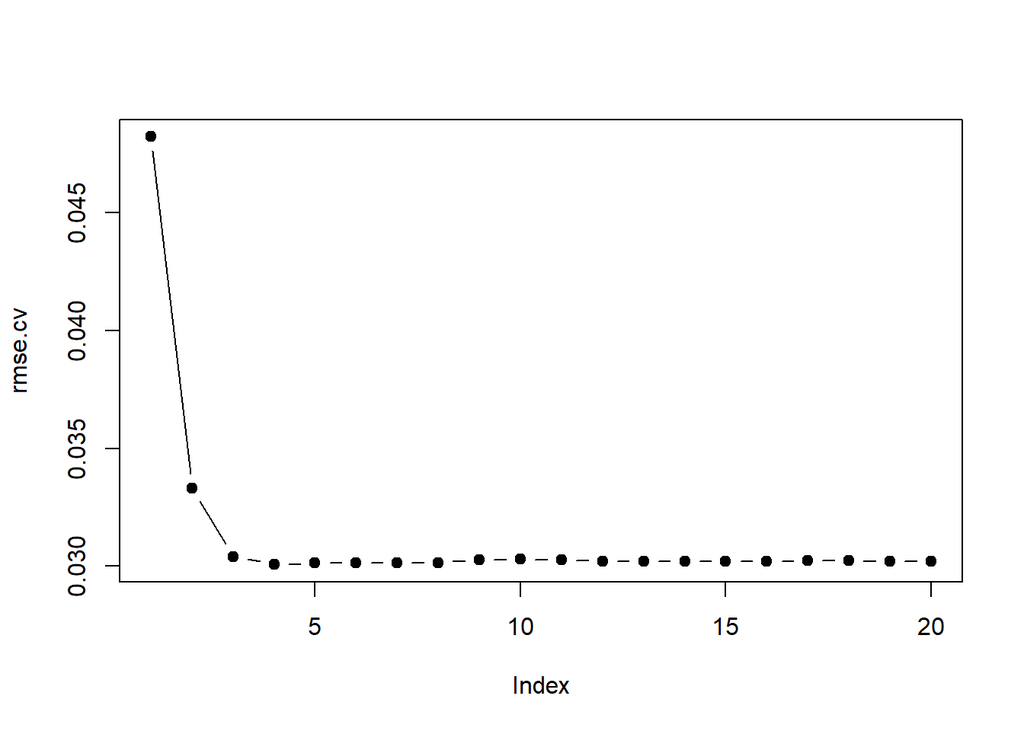

```r
plot(rmse.cv,pch=19,type="b")
```

```r
reg.best=regsubsets (lbwght~.,data=datos.train , nvmax=nvariables)
coef(reg.best ,which.min(rmse.cv))
```

```
  (Intercept)         bwght         fmaps           lbw          vlbw
 7.0123631237  0.0002976461  0.0105802459 -0.1543394286 -0.3309693951
```

```r
# Modelo final acorde a las la mejor selección de conjuntos
fit.final <- lm(lbwght ~ bwght + fmaps + lbw + vlbw, data = datos.train)
summary(fit.final)
```

```
Call:
lm(formula = lbwght ~ bwght + fmaps + lbw + vlbw, data = datos.train)

Residuals:
     Min       1Q   Median       3Q      Max
-0.51461 -0.00406  0.00584  0.01070  0.26192

Coefficients:
              Estimate Std. Error t value Pr(>|t|)
(Intercept)  7.012e+00  1.703e-02 411.683  < 2e-16 ***
bwght        2.976e-04  1.585e-06 187.769  < 2e-16 ***
fmaps        1.058e-02  1.834e-03   5.768 1.04e-08 ***
lbw         -1.543e-01  9.002e-03 -17.145  < 2e-16 ***
vlbw        -3.310e-01  1.373e-02 -24.109  < 2e-16 ***
---
Signif. codes:  0 '***' 0.001 '**' 0.01 '*' 0.05 '.' 0.1 ' ' 1

Residual standard error: 0.02708 on 1123 degrees of freedom
Multiple R-squared:  0.9801,    Adjusted R-squared:   0.98
F-statistic: 1.381e+04 on 4 and 1123 DF,  p-value: < 2.2e-16
```

```r
regfit.full=regsubsets(lbwght~.,data= datos[train,],nvmax=nvariables)

lm.pred = predict.regsubsets(regfit.full, newdata = datos.test, id=which.min(rmse.cv))
error.mss <- mean((datos.test[, "lbwght"] - lm.pred)^2)
error.mss
```

```
[1] 0.000511914
```

```r
results["MCO with Subset Selection", "10 Cross Validation"] = error.mss
```

El error de prueba obtenido es mas pequeño que con el MCO ordinario.

#### c)

```r
nvariables <- as.numeric(dim(datos)[2] - 1)
regfit.full = regsubsets(lbwght~., data=datos[train,], nvmax=nvariables, method = "forward")

k = 10
set.seed(100)
folds=sample(1:k,nrow(datos.train),replace=TRUE)

table(folds)
```

```
folds
  1   2   3   4   5   6   7   8   9  10
 97 100 109 129 107 103 120 120 112 131
```

```r
cv.errors=matrix(NA,k,nvariables, dimnames =list(NULL , paste(1:nvariables)))
for(j in 1:k){
  best.fit=regsubsets(lbwght~.,data=datos.train[folds!=j,],
                      nvmax=nvariables, method = "forward")
  for(i in 1:nvariables){
    pred=predict.regsubsets(best.fit,datos.train[folds==j,],id=i)
    cv.errors[j,i]=mean( (datos.train$lbwght[folds==j]-pred)^2)
  }
}
rmse.cv=sqrt(apply(cv.errors,2,mean))
rmse.cv
```

```
         1          2          3          4          5          6
0.04821566 0.03330704 0.03041755 0.03007367 0.03013112 0.03015472
         7          8          9         10         11         12
0.03015426 0.03015431 0.03022841 0.03023027 0.03022682 0.03018473
        13         14         15         16         17         18
0.03019260 0.03018360 0.03018362 0.03021553 0.03022206 0.03022344
        19         20
0.03022860 0.03022142
```

```r
which.min(rmse.cv)
```

```
4
4
```

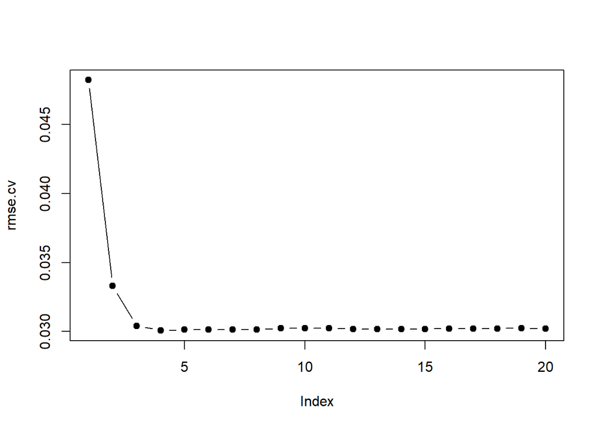

```r
plot(rmse.cv,pch=19,type="b")
```

```r
reg.best=regsubsets (lbwght~.,data=datos.train , nvmax=nvariables, method = "forward")
coef(reg.best ,which.min(rmse.cv))
```

```
  (Intercept)         bwght         fmaps           lbw          vlbw
 7.0123631237  0.0002976461  0.0105802459 -0.1543394286 -0.3309693951
```

```r
# Modelo final acorde a las la mejor selección de conjuntos
fit.final <- lm(lbwght ~ bwght + fmaps + lbw + vlbw, data = datos.train)
summary(fit.final)
```

```
Call:
lm(formula = lbwght ~ bwght + fmaps + lbw + vlbw, data = datos.train)

Residuals:
     Min       1Q   Median       3Q      Max
-0.51461 -0.00406  0.00584  0.01070  0.26192

Coefficients:
              Estimate Std. Error t value Pr(>|t|)
(Intercept)  7.012e+00  1.703e-02 411.683  < 2e-16 ***
bwght        2.976e-04  1.585e-06 187.769  < 2e-16 ***
fmaps        1.058e-02  1.834e-03   5.768 1.04e-08 ***
lbw         -1.543e-01  9.002e-03 -17.145  < 2e-16 ***
vlbw        -3.310e-01  1.373e-02 -24.109  < 2e-16 ***
---
Signif. codes:  0 '***' 0.001 '**' 0.01 '*' 0.05 '.' 0.1 ' ' 1

Residual standard error: 0.02708 on 1123 degrees of freedom
Multiple R-squared:  0.9801,    Adjusted R-squared:   0.98
F-statistic: 1.381e+04 on 4 and 1123 DF,  p-value: < 2.2e-16
```

```r
regfit.full=regsubsets(lbwght~.,data= datos[train,],nvmax=nvariables, method = "forward")

lm.pred = predict.regsubsets(regfit.full, newdata = datos.test, id=which.min(rmse.cv))
error.mss <- mean((datos.test[, "lbwght"] - lm.pred)^2)
error.mss
```

```
[1] 0.000511914
```

```r
results["MCO with Forward step wise", "10 Cross Validation"] = error.mss
```

#### d)

```r
nvariables <- as.numeric(dim(datos)[2] - 1)
regfit.full = regsubsets(lbwght~., data=datos[train,], nvmax=nvariables)

predict.regsubsets=function(object, newdata, id, ...) {
  form=as.formula(object$call[[2]])
  mat=model.matrix(form,newdata)
  coefi=coef(object,id=id)
  xvars=names(coefi)
  mat[,xvars]%*%coefi
}

k = 5
set.seed(100)
folds=sample(1:k,nrow(datos.train),replace=TRUE)

table(folds)
```

```
folds
  1   2   3   4   5
197 238 210 240 243
```

```r
cv.errors=matrix(NA,k,nvariables, dimnames =list(NULL , paste(1:nvariables)))
for(j in 1:k){
  best.fit=regsubsets(lbwght~.,data=datos.train[folds!=j,],
                      nvmax=nvariables)
  for(i in 1:nvariables){
    pred=predict.regsubsets(best.fit,datos.train[folds==j,],id=i)
    cv.errors[j,i]=mean( (datos.train$lbwght[folds==j]-pred)^2)
  }
}
rmse.cv=sqrt(apply(cv.errors,2,mean))
rmse.cv
```

```
         1          2          3          4          5          6
0.04724912 0.03348780 0.03056028 0.03030288 0.03039083 0.03039898
         7          8          9         10         11         12
0.03048605 0.03045558 0.03052369 0.03053467 0.03051360 0.03051497
        13         14         15         16         17         18
0.03049662 0.03048933 0.03050103 0.03051083 0.03050089 0.03050719
        19         20
0.03050598 0.03050462
```

```r
which.min(rmse.cv)
```

```
4
4
```

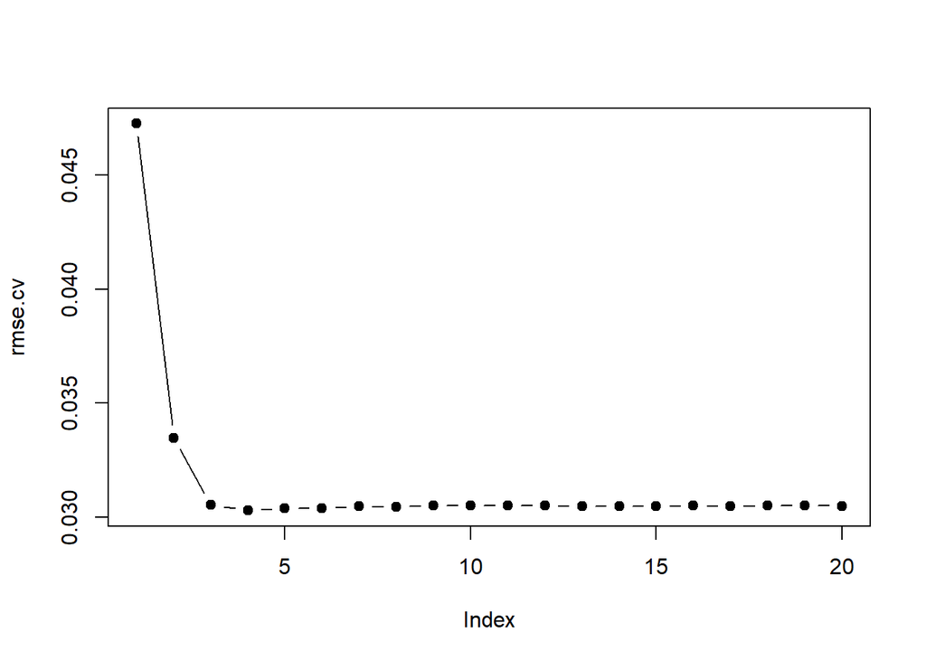

```r
plot(rmse.cv,pch=19,type="b")
```

```r
reg.best=regsubsets (lbwght~.,data=datos.train , nvmax=nvariables)
coef(reg.best ,which.min(rmse.cv))
```

```
  (Intercept)         bwght         fmaps           lbw          vlbw
 7.0123631237  0.0002976461  0.0105802459 -0.1543394286 -0.3309693951
```

```r
# Modelo final acorde a las la mejor selección de conjuntos
fit.final <- lm(lbwght ~ bwght + fmaps + lbw + vlbw, data = datos.train)
summary(fit.final)
```

```
Call:
lm(formula = lbwght ~ bwght + fmaps + lbw + vlbw, data = datos.train)

Residuals:
     Min       1Q   Median       3Q      Max
-0.51461 -0.00406  0.00584  0.01070  0.26192

Coefficients:
              Estimate Std. Error t value Pr(>|t|)
(Intercept)  7.012e+00  1.703e-02 411.683  < 2e-16 ***
bwght        2.976e-04  1.585e-06 187.769  < 2e-16 ***
fmaps        1.058e-02  1.834e-03   5.768 1.04e-08 ***
lbw         -1.543e-01  9.002e-03 -17.145  < 2e-16 ***
vlbw        -3.310e-01  1.373e-02 -24.109  < 2e-16 ***
---
Signif. codes:  0 '***' 0.001 '**' 0.01 '*' 0.05 '.' 0.1 ' ' 1

Residual standard error: 0.02708 on 1123 degrees of freedom
Multiple R-squared:  0.9801,    Adjusted R-squared:   0.98
F-statistic: 1.381e+04 on 4 and 1123 DF,  p-value: < 2.2e-16
```

```r
regfit.full=regsubsets(lbwght~.,data= datos[train,],nvmax=nvariables)

lm.pred = predict.regsubsets(regfit.full, newdata = datos.test, id=which.min(rmse.cv))
error.mss <- mean((datos.test[, "lbwght"] - lm.pred)^2)
error.mss
```

```
[1] 0.000511914
```

```r
results["MCO with Subset Selection", "5 Cross Validation"] = error.mss
```

```r
nvariables <- as.numeric(dim(datos)[2] - 1)
regfit.full = regsubsets(lbwght~., data=datos[train,], nvmax=nvariables, method = "forward")

k = 5
set.seed(100)
folds=sample(1:k,nrow(datos.train),replace=TRUE)

table(folds)
```

```
folds
  1   2   3   4   5
197 238 210 240 243
```

```r
cv.errors=matrix(NA,k,nvariables, dimnames =list(NULL , paste(1:nvariables)))
for(j in 1:k){
  best.fit=regsubsets(lbwght~.,data=datos.train[folds!=j,],
                      nvmax=nvariables, method = "forward")
  for(i in 1:nvariables){
    pred=predict.regsubsets(best.fit,datos.train[folds==j,],id=i)
    cv.errors[j,i]=mean( (datos.train$lbwght[folds==j]-pred)^2)
  }
}
rmse.cv=sqrt(apply(cv.errors,2,mean))
rmse.cv
```

```
         1          2          3          4          5          6
0.04724912 0.03348780 0.03056028 0.03030288 0.03039083 0.03039898
         7          8          9         10         11         12
0.03052785 0.03050632 0.03047763 0.03051874 0.03049464 0.03050382
        13         14         15         16         17         18
0.03047868 0.03047105 0.03047792 0.03048737 0.03048974 0.03048264
        19         20
0.03050674 0.03050462
```

```r
which.min(rmse.cv)
```

```
4
4
```

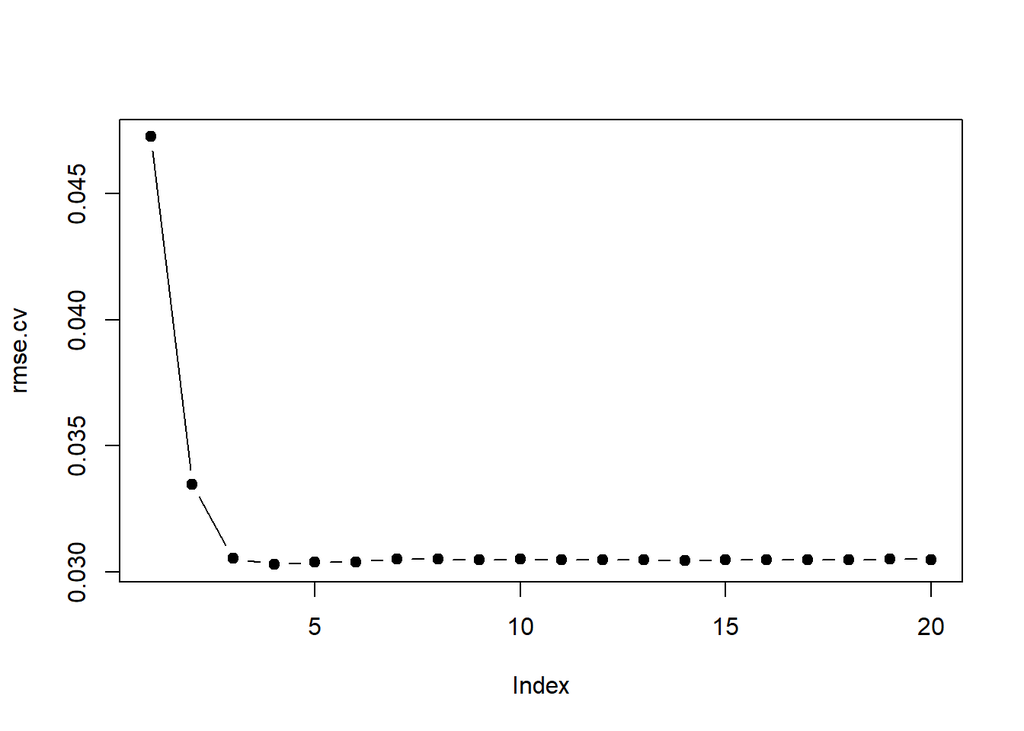

```r
plot(rmse.cv,pch=19,type="b")
```

```r
reg.best=regsubsets (lbwght~.,data=datos.train , nvmax=nvariables, method = "forward")
coef(reg.best ,which.min(rmse.cv))
```

```
  (Intercept)         bwght         fmaps           lbw          vlbw
 7.0123631237  0.0002976461  0.0105802459 -0.1543394286 -0.3309693951
```

```r
# Modelo final acorde a las la mejor selección de conjuntos
fit.final <- lm(lbwght ~ bwght + fmaps + lbw + vlbw, data = datos.train)
summary(fit.final)
```

```
Call:
lm(formula = lbwght ~ bwght + fmaps + lbw + vlbw, data = datos.train)

Residuals:
     Min       1Q   Median       3Q      Max
-0.51461 -0.00406  0.00584  0.01070  0.26192

Coefficients:
              Estimate Std. Error t value Pr(>|t|)
(Intercept)  7.012e+00  1.703e-02 411.683  < 2e-16 ***
bwght        2.976e-04  1.585e-06 187.769  < 2e-16 ***
fmaps        1.058e-02  1.834e-03   5.768 1.04e-08 ***
lbw         -1.543e-01  9.002e-03 -17.145  < 2e-16 ***
vlbw        -3.310e-01  1.373e-02 -24.109  < 2e-16 ***
---
Signif. codes:  0 '***' 0.001 '**' 0.01 '*' 0.05 '.' 0.1 ' ' 1

Residual standard error: 0.02708 on 1123 degrees of freedom
Multiple R-squared:  0.9801,    Adjusted R-squared:   0.98
F-statistic: 1.381e+04 on 4 and 1123 DF,  p-value: < 2.2e-16
```

```r
regfit.full=regsubsets(lbwght~.,data= datos[train,],nvmax=nvariables, method = "forward")

lm.pred = predict.regsubsets(regfit.full, newdata = datos.test, id=which.min(rmse.cv))
error.mss <- mean((datos.test[, "lbwght"] - lm.pred)^2)
error.mss
```

```
[1] 0.000511914
```

```r
results["MCO with Forward step wise", "5 Cross Validation"] = error.mss
```

#### e)

A continuación se muestran los modelos utilizados anteriormente con el tipo de validación cruzada y su error de prueba correspondiente.

```r
kable(results)
```

[output not shown]

#### f)

Para seleccionar el modelo que minimiza el error, como no hay mucha diferencia entre los errores anteriores, escogimos el último modelo analizado **MCO with Forward step wise**. En el análisis de este modelo se determinaron las variables significativas al 5%, son las que se usan a continuación.

```r
fit.final <- lm(lbwght ~ bwght + fmaps + lbw + vlbw, data = datos.train)

lm.pred <- predict.regsubsets(fit.final, newdata = datos.test)
error.new =  mean((datos.test[, "lbwght"] - lm.pred)^2)
error.new
```

```
[1] 0.000511914
```

Los **p-valores** se muestran a continuación:

```r
summary(fit.final)[4]
```

```
$coefficients
                 Estimate   Std. Error    t value      Pr(>|t|)
(Intercept)  7.0123631237 1.703342e-02 411.682667  0.000000e+00
bwght        0.0002976461 1.585174e-06 187.768796  0.000000e+00
fmaps        0.0105802459 1.834398e-03   5.767694  1.038118e-08
lbw         -0.1543394286 9.001872e-03 -17.145259  1.041566e-58
vlbw        -0.3309693951 1.372829e-02 -24.108564 7.864423e-104
```

#### g)

Regresión de Ridge

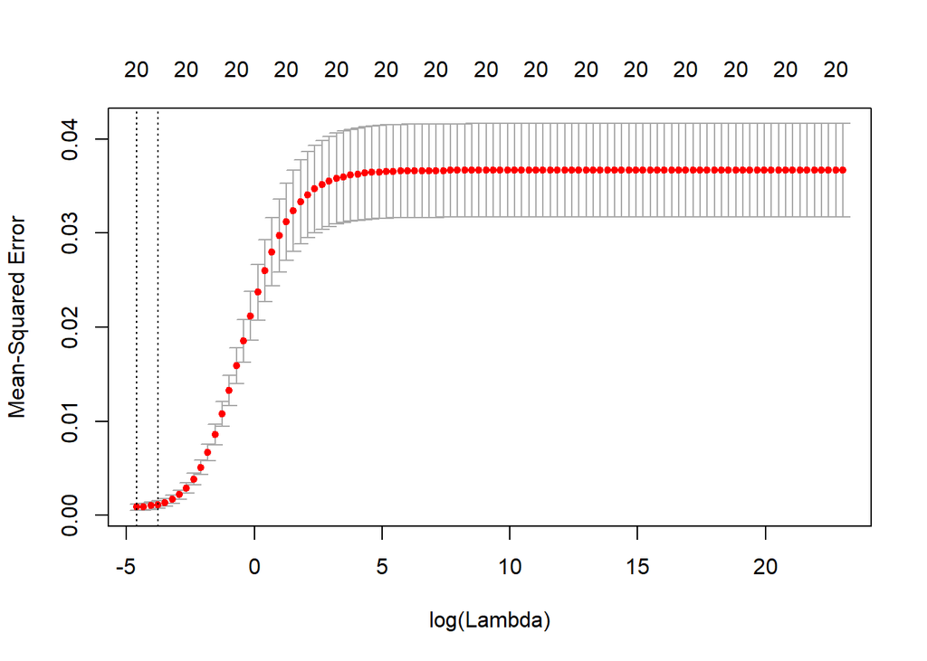

```r
set.seed(100)
library(glmnet)
x=model.matrix(lbwght~.,datos)[,-1]
y=datos$lbwght
y.test=y[test]
grid=10^seq(10,-2, length =100)
cv.ridge=cv.glmnet(x[train ,],y[train],alpha=0,lambda=grid)
plot(cv.ridge)
```

```r
mejorlambda=cv.ridge$lambda.min
mejorlambda
```

```
[1] 0.01
```

```r
ridge.mod=glmnet(x[train ,],y[train],alpha=0,lambda=grid)
ridge.pred=predict(ridge.mod,s=mejorlambda ,newx=x[test ,])

error.ridge <- mean((ridge.pred-datos.test[, "lbwght"] )^2)
error.ridge
```

```
[1] 0.0005855056
```

```r
results2["RIDGE", "10 Cross Validation"] = error.ridge

# Regla del "codo" de una DT del error de VC:
lambda.codo <- cv.ridge$lambda.1se
lambda.codo
```

```
[1] 0.0231013
```

```r
ridge.pred.2=predict(ridge.mod,s=lambda.codo,newx=x[test ,])
error.ridge.2 <- mean((ridge.pred.2-datos.test[, "lbwght"] )^2)
error.ridge.2
```

```
[1] 0.000850785
```

#### h)

Modelo de LASSO

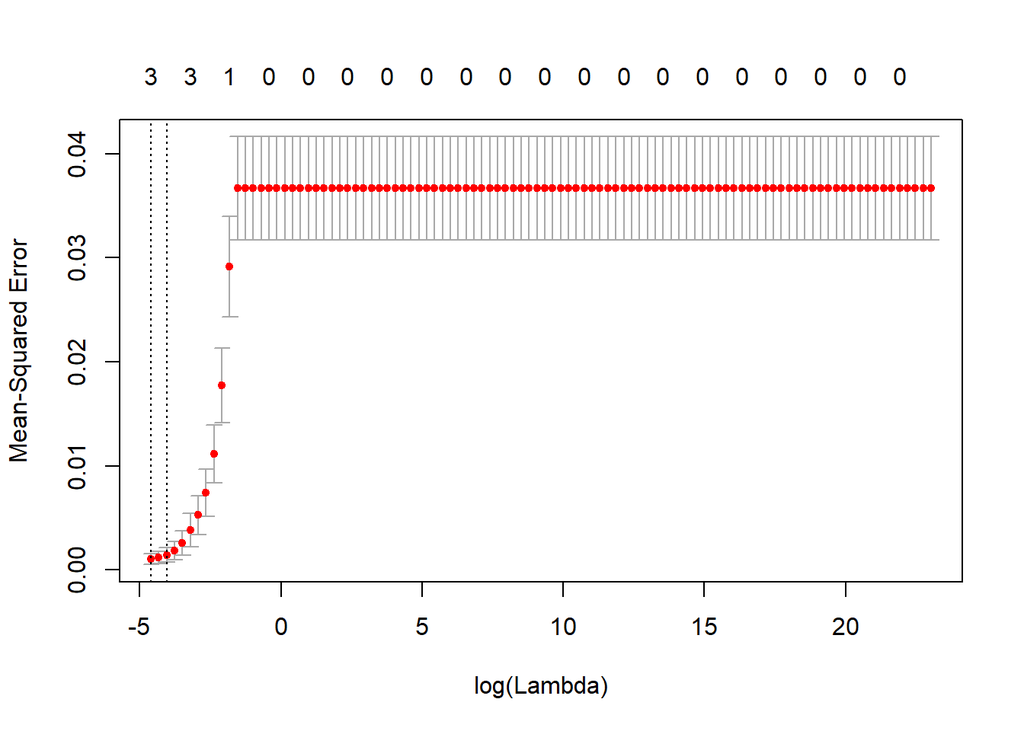

```r
set.seed(100)
cv.lasso=cv.glmnet(x[train ,],y[train],alpha=1, lambda = grid)
plot(cv.lasso)
```

```r
bestlam=cv.lasso$lambda.min
bestlam
```

```
[1] 0.01
```

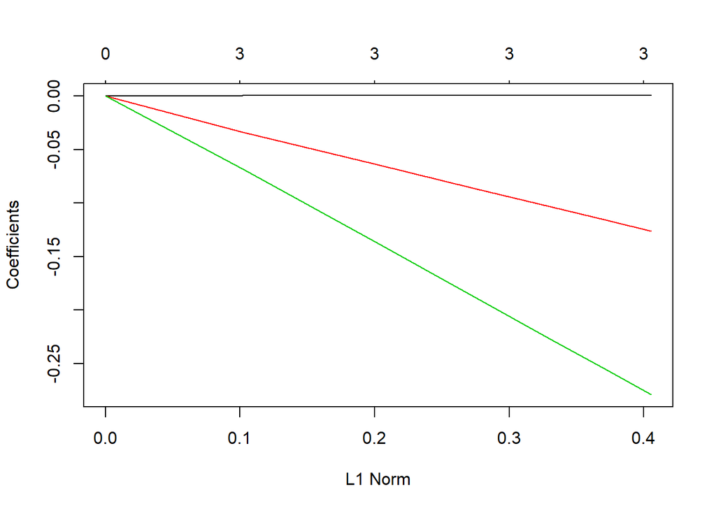

```r
lasso.mod=glmnet(x[train ,],y[train],alpha=1,lambda=grid)
plot(lasso.mod)
```

```r
lasso.pred=predict(lasso.mod,s=bestlam,newx=x[test ,])

error.lasso <- mean((lasso.pred-datos.test[, "lbwght"] )^2)
error.lasso
```

```
[1] 0.000435723
```

```r
results2["LASSO", "10 Cross Validation"] = error.lasso

# Regla del "codo" de una DT del error de VC:
lambda.codo.l <- cv.lasso$lambda.1se
lambda.codo.l
```

```
[1] 0.01747528
```

```r
lasso.pred.2=predict(lasso.mod,s=lambda.codo.l,newx=x[test ,])
error.lasso.2 <- mean((lasso.pred.2-datos.test[, "lbwght"] )^2)
error.lasso.2
```

```
[1] 0.0005318692
```

Para obtener los coeficientes del modelo para el mejor lambda usamos la función coef

```r
c = coef(lasso.mod, s = bestlam)
c
```

```
21 x 1 sparse Matrix of class "dgCMatrix"
                        1
(Intercept)  7.1446826417
mage         .
meduc        .
monpre       .
npvis        .
fage         .
feduc        .
bwght        0.0002865851
omaps        .
fmaps        .
cigs         .
drink        .
lbw         -0.1261450669
vlbw        -0.2789833877
male         .
mwhte        .
mblck        .
fwhte        .
fblck        .
magesq       .
npvissq      .
```

Los coeficientes diferentes de 0 son 3.

#### i)

Regresión de Ridge con CV 5 veces

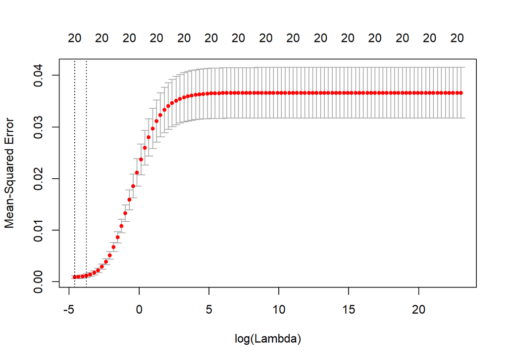

```r
set.seed(100)
library(glmnet)
x=model.matrix(lbwght~.,datos)[,-1]
y=datos$lbwght
y.test=y[test]
grid=10^seq(10,-2, length =100)
cv.ridge=cv.glmnet(x[train ,],y[train],alpha=0,lambda=grid, nfolds = 5)
plot(cv.ridge)
```

```r
mejorlambda=cv.ridge$lambda.min
mejorlambda
```

```
[1] 0.01
```

```r
ridge.mod=glmnet(x[train ,],y[train],alpha=0,lambda=grid)
ridge.pred=predict(ridge.mod,s=mejorlambda ,newx=x[test ,])

error.ridge <- mean((ridge.pred-datos.test[, "lbwght"] )^2)
error.ridge
```

```
[1] 0.0005855056
```

```r
results2["RIDGE", "5 Cross Validation"] = error.ridge
```

Modelo de LASSO

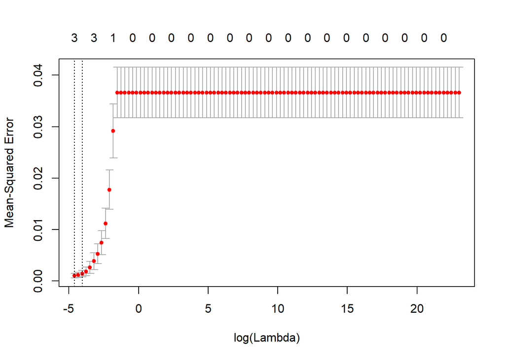

```r
set.seed(100)
cv.lasso=cv.glmnet(x[train ,],y[train],alpha=1, lambda = grid, nfolds = 5)
plot(cv.lasso)
```

```r
bestlam=cv.lasso$lambda.min
bestlam
```

```
[1] 0.01
```

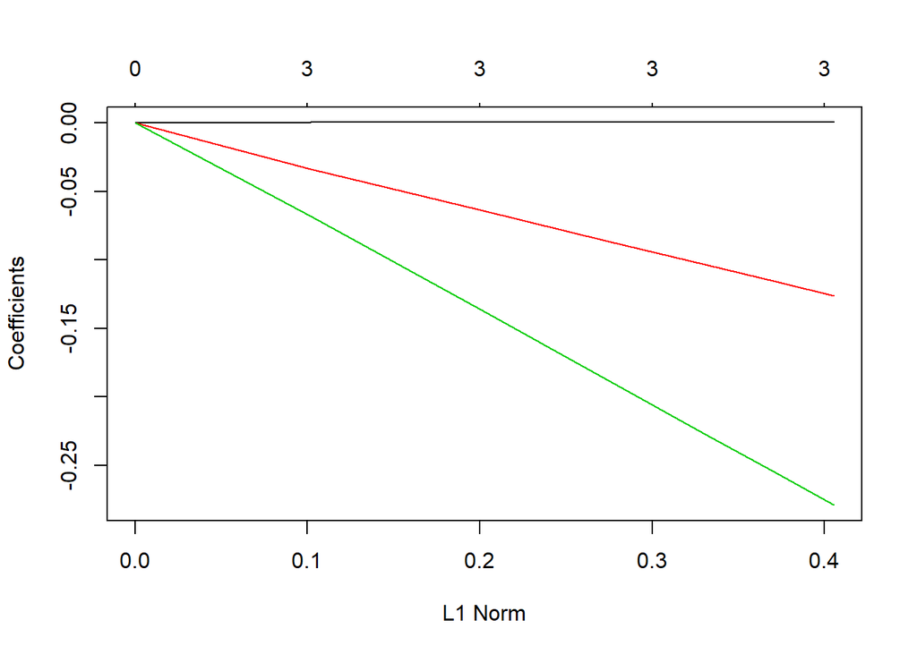

```r
lasso.mod=glmnet(x[train ,],y[train],alpha=1,lambda=grid)
plot(lasso.mod)
```

```r
lasso.pred=predict(lasso.mod,s=bestlam,newx=x[test ,])

error.lasso <- mean((lasso.pred-datos.test[, "lbwght"] )^2)
error.lasso
```

```
[1] 0.000435723
```

```r
results2["LASSO", "5 Cross Validation"] = error.lasso
```

Para obtener los coeficientes del modelo para el mejor lambda usamos la función coef

```r
c = coef(lasso.mod, s = bestlam)
c
```

```
21 x 1 sparse Matrix of class "dgCMatrix"
                        1
(Intercept)  7.1446826417
mage         .
meduc        .
monpre       .
npvis        .
fage         .
feduc        .
bwght        0.0002865851
omaps        .
fmaps        .
cigs         .
drink        .
lbw         -0.1261450669
vlbw        -0.2789833877
male         .
mwhte        .
mblck        .
fwhte        .
fblck        .
magesq       .
npvissq      .
```

Los coeficientes diferentes de 0 son 3.

#### j)

```r
library(pls)
set.seed(100)
pcr.fit=pcr(lbwght~., data=datos,subset=train,scale=TRUE, validation="CV")
summary(pcr.fit)
```

```
Data:   X dimension: 1128 20
    Y dimension: 1128 1
Fit method: svdpc
Number of components considered: 20

VALIDATION: RMSEP
Cross-validated using 10 random segments.
       (Intercept)  1 comps  2 comps  3 comps  4 comps  5 comps  6 comps
CV          0.1915   0.1892   0.1875   0.1420   0.1352   0.1354   0.1227
adjCV       0.1915   0.1892   0.1875   0.1415   0.1350   0.1353   0.1210
       7 comps  8 comps  9 comps  10 comps  11 comps  12 comps  13 comps
CV      0.1179   0.1091   0.1080    0.1078   0.04523   0.03479   0.03552
adjCV   0.1160   0.1087   0.1078    0.1081   0.04464   0.03412   0.03515
       14 comps  15 comps  16 comps  17 comps  18 comps  19 comps
CV      0.03409   0.03372   0.03071   0.03073   0.03076   0.03077
adjCV   0.03396   0.03368   0.03050   0.03052   0.03055   0.03056
       20 comps
CV      0.03085
adjCV   0.03064

TRAINING: % variance explained
        1 comps  2 comps  3 comps  4 comps  5 comps  6 comps  7 comps
X        17.186   32.312    44.07    53.67    60.79    66.51    71.64
lbwght    3.228    6.003    47.20    52.10    52.19    66.74    69.55
        8 comps  9 comps  10 comps  11 comps  12 comps  13 comps  14 comps
X         76.75    80.83     84.77     88.28     90.92     93.30     95.43
lbwght    70.31    70.49     70.52     94.99     97.18     97.18     97.45
        15 comps  16 comps  17 comps  18 comps  19 comps  20 comps
X          97.30     98.86     99.53     99.80     99.97    100.00
lbwght     97.52     98.03     98.03     98.03     98.03     98.04
```

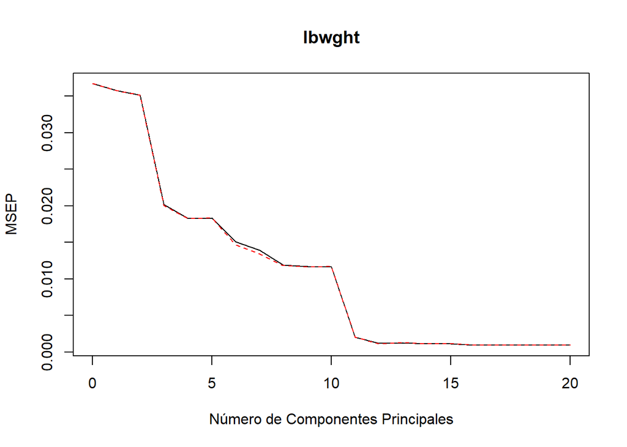

```r
validationplot(pcr.fit,val.type="MSEP", xlab = "Número de Componentes Principales")
```

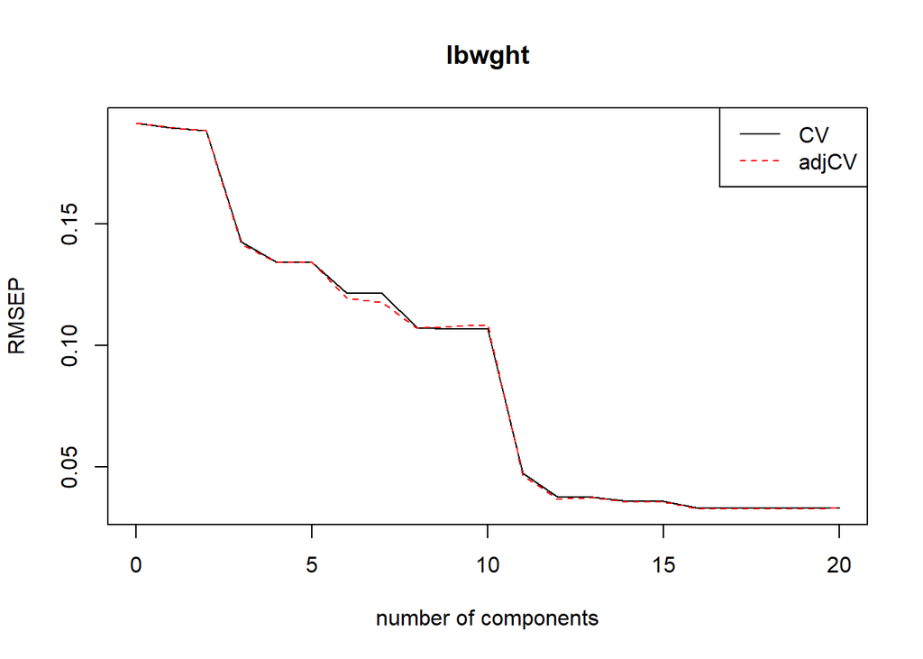

```r
pcr.cv <- crossval(pcr.fit, segments = 10)
plot(RMSEP(pcr.cv), legendpos="topright")
```

```r
summary(pcr.cv, what = "validation")
```

```
Data:   X dimension: 1128 20
    Y dimension: 1128 1
Fit method: svdpc
Number of components considered: 20

VALIDATION: RMSEP
Cross-validated using 10 random segments.
       (Intercept)  1 comps  2 comps  3 comps  4 comps  5 comps  6 comps
CV          0.1915   0.1896   0.1885   0.1428   0.1344   0.1344   0.1217
adjCV       0.1915   0.1897   0.1885   0.1420   0.1342   0.1343   0.1195
       7 comps  8 comps  9 comps  10 comps  11 comps  12 comps  13 comps
CV      0.1216   0.1076    0.107    0.1070   0.04754   0.03762   0.03783
adjCV   0.1179   0.1073    0.108    0.1085   0.04679   0.03684   0.03738
       14 comps  15 comps  16 comps  17 comps  18 comps  19 comps
CV      0.03610   0.03595   0.03319   0.03320   0.03325   0.03325
adjCV   0.03582   0.03576   0.03284   0.03286   0.03291   0.03290
       20 comps
CV      0.03341
adjCV   0.03306
```

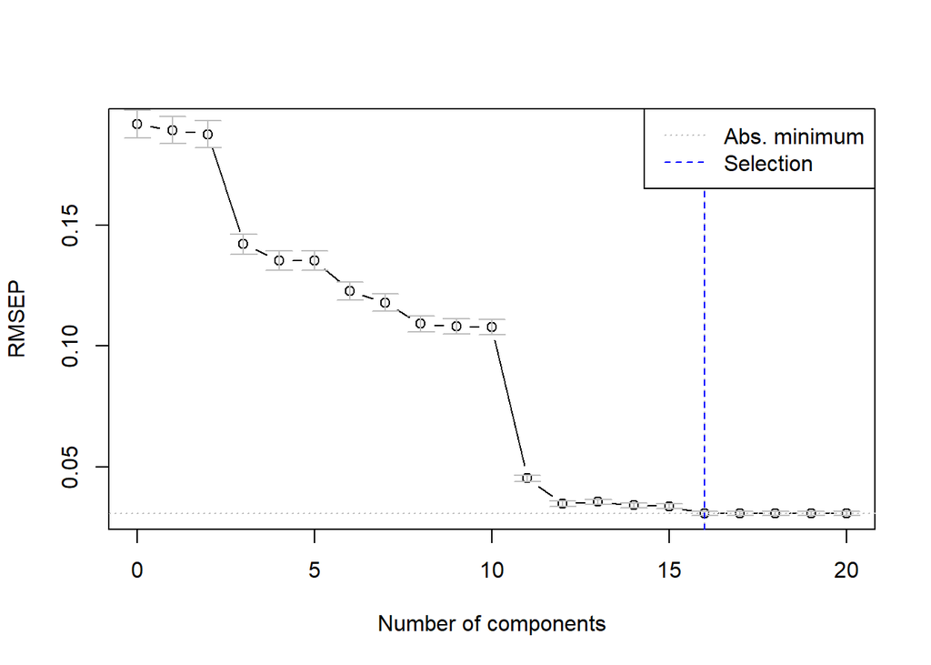

```r
## Selecciona el número de componentes principales
## Regla del codo: 1 d.t.
ncomp.1.d.t. <- selectNcomp(pcr.fit, method = "onesigma", plot = TRUE, validation = "CV",
                            segments = 10)
```

```r
ncomp.1.d.t.
```

```
[1] 16
```

```r
pcr.pred=predict(pcr.fit,newdata=x[test,],ncomp=ncomp.1.d.t.)
error.pcr <- mean((pcr.pred - datos.test[, "lbwght"])^2)
error.pcr
```

```
[1] 0.0005175971
```

```r
results2["PCA", "10 Cross Validation"] = error.pcr
```

Usando el Metodo de Componentes Principales con una Validación Cruzada 10 veces obtenemos la cantidad de componentes M = 16 y un error de prueba de 5.175971410^{-4}.

El mismo método pero con la validación cruzada 5 veces seria:

```r
set.seed(100)
pcr.fit=pcr(lbwght~., data=datos,subset=train,scale=TRUE, validation="CV")
summary(pcr.fit)
```

```
Data:   X dimension: 1128 20
    Y dimension: 1128 1
Fit method: svdpc
Number of components considered: 20

VALIDATION: RMSEP
Cross-validated using 10 random segments.
       (Intercept)  1 comps  2 comps  3 comps  4 comps  5 comps  6 comps
CV          0.1915   0.1892   0.1875   0.1420   0.1352   0.1354   0.1227
adjCV       0.1915   0.1892   0.1875   0.1415   0.1350   0.1353   0.1210
       7 comps  8 comps  9 comps  10 comps  11 comps  12 comps  13 comps
CV      0.1179   0.1091   0.1080    0.1078   0.04523   0.03479   0.03552
adjCV   0.1160   0.1087   0.1078    0.1081   0.04464   0.03412   0.03515
       14 comps  15 comps  16 comps  17 comps  18 comps  19 comps
CV      0.03409   0.03372   0.03071   0.03073   0.03076   0.03077
adjCV   0.03396   0.03368   0.03050   0.03052   0.03055   0.03056
       20 comps
CV      0.03085
adjCV   0.03064

TRAINING: % variance explained
        1 comps  2 comps  3 comps  4 comps  5 comps  6 comps  7 comps
X        17.186   32.312    44.07    53.67    60.79    66.51    71.64
lbwght    3.228    6.003    47.20    52.10    52.19    66.74    69.55
        8 comps  9 comps  10 comps  11 comps  12 comps  13 comps  14 comps
X         76.75    80.83     84.77     88.28     90.92     93.30     95.43
lbwght    70.31    70.49     70.52     94.99     97.18     97.18     97.45
        15 comps  16 comps  17 comps  18 comps  19 comps  20 comps
X          97.30     98.86     99.53     99.80     99.97    100.00
lbwght     97.52     98.03     98.03     98.03     98.03     98.04
```

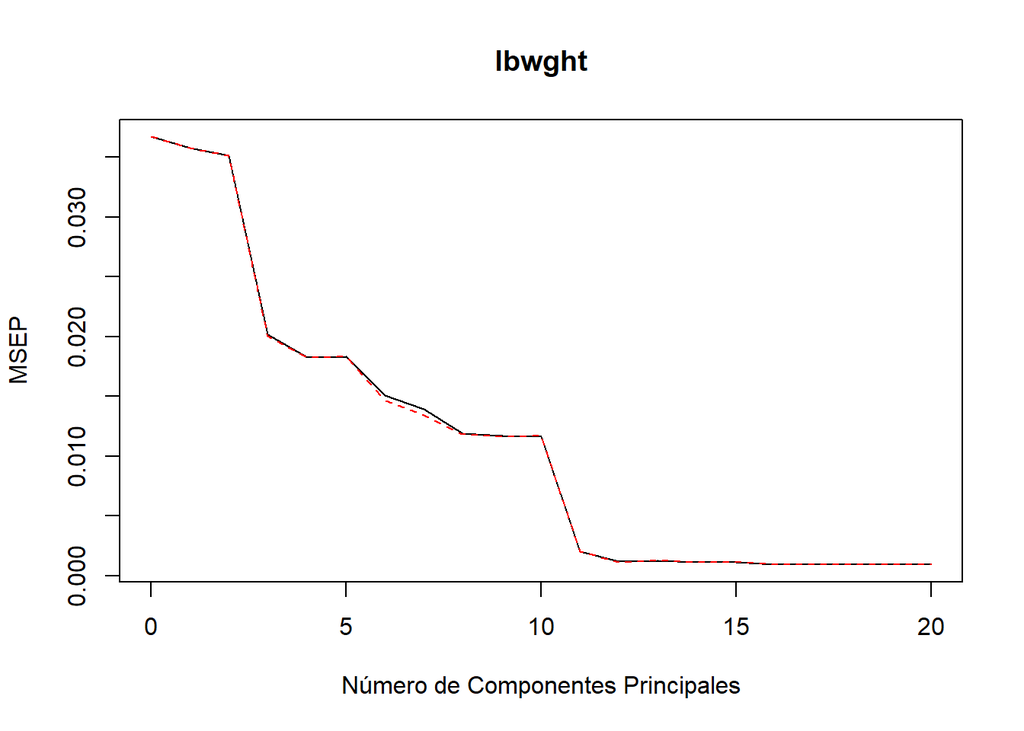

```r
validationplot(pcr.fit,val.type="MSEP", xlab = "Número de Componentes Principales")
```

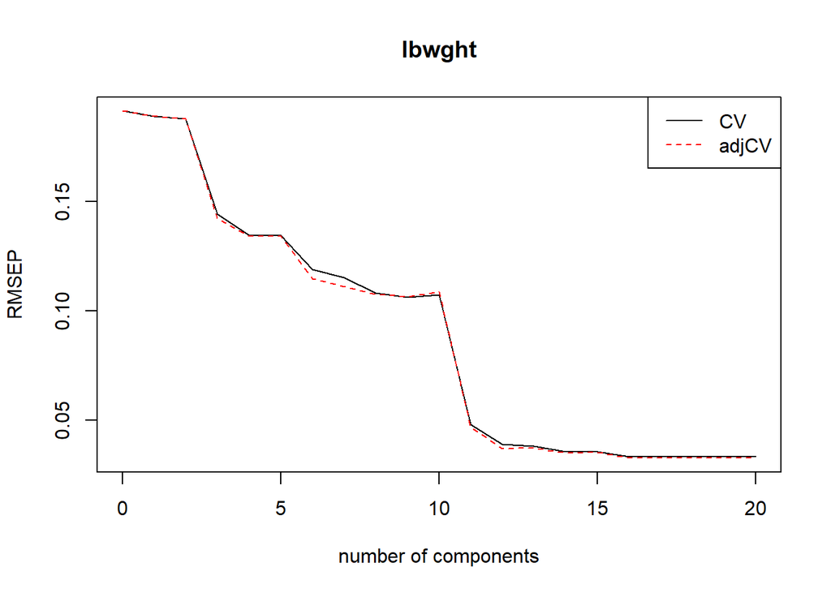

```r
pcr.cv <- crossval(pcr.fit, segments = 5)
plot(RMSEP(pcr.cv), legendpos="topright")
```

```r
summary(pcr.cv, what = "validation")
```

```
Data:   X dimension: 1128 20
    Y dimension: 1128 1
Fit method: svdpc
Number of components considered: 20

VALIDATION: RMSEP
Cross-validated using 5 random segments.
       (Intercept)  1 comps  2 comps  3 comps  4 comps  5 comps  6 comps
CV          0.1915   0.1890   0.1879   0.1443   0.1344   0.1345   0.1189
adjCV       0.1915   0.1891   0.1881   0.1425   0.1342   0.1343   0.1149
       7 comps  8 comps  9 comps  10 comps  11 comps  12 comps  13 comps
CV      0.1154   0.1082   0.1063    0.1073   0.04799   0.03897   0.03801
adjCV   0.1109   0.1077   0.1066    0.1089   0.04688   0.03697   0.03727
       14 comps  15 comps  16 comps  17 comps  18 comps  19 comps
CV      0.03550   0.03569   0.03342   0.03342   0.03346   0.03346
adjCV   0.03494   0.03530   0.03270   0.03271   0.03274   0.03274
       20 comps
CV      0.03361
adjCV   0.03288
```

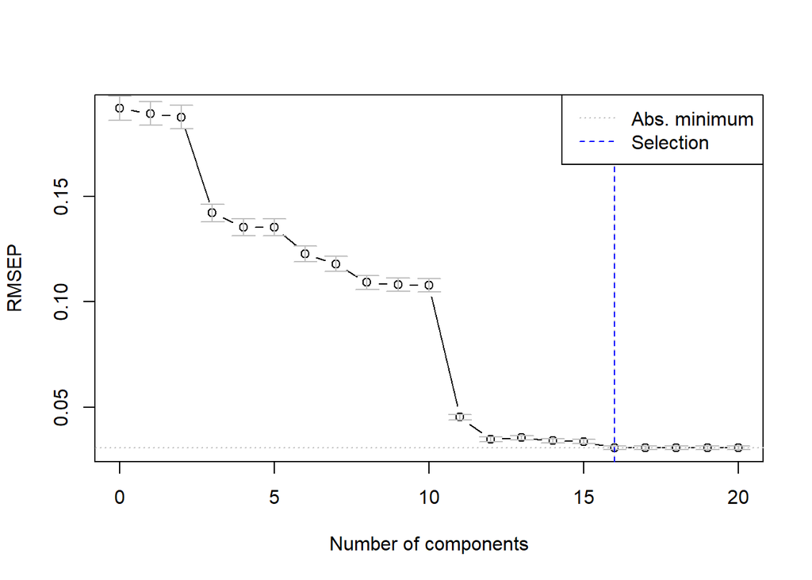

```r
## Selecciona el número de componentes principales
## Regla del codo: 1 d.t.
ncomp.1.d.t. <- selectNcomp(pcr.fit, method = "onesigma", plot = TRUE, validation = "CV",
                            segments = 5)
```

```r
ncomp.1.d.t.
```

```
[1] 16
```

```r
pcr.pred=predict(pcr.fit,newdata=x[test,],ncomp=ncomp.1.d.t.)
error.pcr <- mean((pcr.pred - datos.test[, "lbwght"])^2)
error.pcr
```

```
[1] 0.0005175971
```

```r
results2["PCA", "5 Cross Validation"] = error.pcr
```

Usando el Metodo de Componentes Principales con una Validación Cruzada 5 veces obtenemos la cantidad de componentes M = 16 y un error de prueba de 5.175971410^{-4}.